# Pilot for CCP6 (contextual patience manipulation) - fun vs. boring videos

# 1. Summary

## 1.1 The patience manipulation drastically increased how much time people spent on the credit card task (they spent almost twice as much time).

## 1.2 The patience manipulation seemed to increase mlweb boxes opened, though this effect was smaller

However, the impatient condition being below chance might be noise.

```r
bfwide<-read.csv("/Users/Kelle/Documents/pilot_ccp6_wide.csv")

library(ggplot2)
library(lme4)
library(lmerTest)
library(tidyr)
```

# 2. DEEP density plots

DEEP distributions look strange with so many above beta = 1. We also had a bunch of “divergent transitions” when using Qi’s script so I’ll see whether this is a problem and whether I can fix it. But DEEP wasn’t a big part of this Pilot.

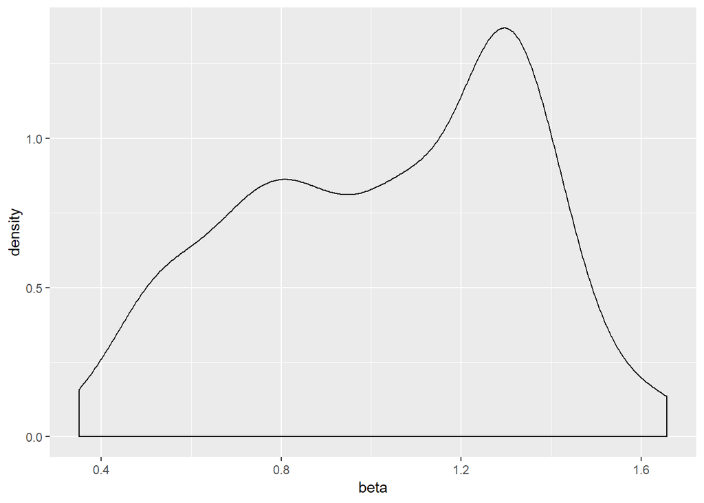

```r
ggplot(bfwide, aes(x = beta)) + geom_density()
```

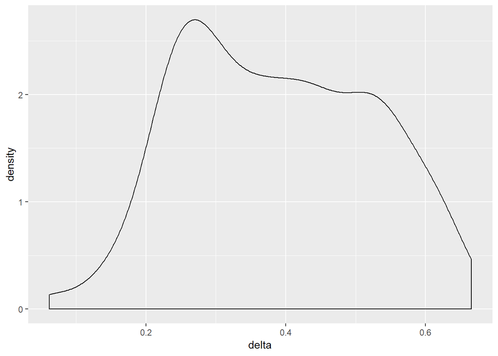

```r
ggplot(bfwide, aes(x = delta)) + geom_density()
```

```r
cor.test(bfwide$beta,bfwide$delta)
```

```
##
##  Pearson's product-moment correlation
##
## data:  bfwide$beta and bfwide$delta
## t = 7.5118, df = 265, p-value = 8.953e-13
## alternative hypothesis: true correlation is not equal to 0
## 95 percent confidence interval:
##  0.3147764 0.5132213
## sample estimates:
##       cor
## 0.4189895
```

```r
bfwidet1<-bfwide[(bfwide$trial==1), ]
```

# 3. Boxes opened and timing summary statistics

## 3.1. Summaries of boxes opened and time searching, by condition

People in the “patient condition” (boring video afterwards) spent more time searching (almost twice as much whether looking at median or mean).

Differences in boxes opened was smaller suggesting impatient people must have opened boxes faster though they also opened about 7 fewer on average.

```r
print(aggregate(searchtime ~ condition, bfwide[-2], summary))
```

```
##   condition searchtime.Min. searchtime.1st Qu. searchtime.Median
## 1    boring         9.12700           69.81000         147.57600
## 2       fun        17.65200           45.45850          79.07500
##   searchtime.Mean searchtime.3rd Qu. searchtime.Max.
## 1       153.95654          205.25450       554.25000
## 2        90.55019          133.83000       209.01900
```

```r
print(aggregate(numopened ~ condition, bfwide[-2], summary))
```

```
##   condition numopened.Min. numopened.1st Qu. numopened.Median
## 1    boring        1.00000          15.50000         27.00000
## 2       fun        1.00000          10.00000         22.00000
##   numopened.Mean numopened.3rd Qu. numopened.Max.
## 1       34.56911          42.50000      224.00000
## 2       27.38194          37.00000      139.00000
```

```r
print(aggregate(correct ~ condition, bfwidet1[-2], summary))
```

```
##   condition correct.Min. correct.1st Qu. correct.Median correct.Mean
## 1    boring    0.0000000       0.0000000      0.0000000    0.3720930
## 2       fun    0.0000000       0.0000000      0.0000000    0.1836735
##   correct.3rd Qu. correct.Max.
## 1       1.0000000    1.0000000
## 2       0.0000000    1.0000000
```

## 3.2 Violin plots to display those differences

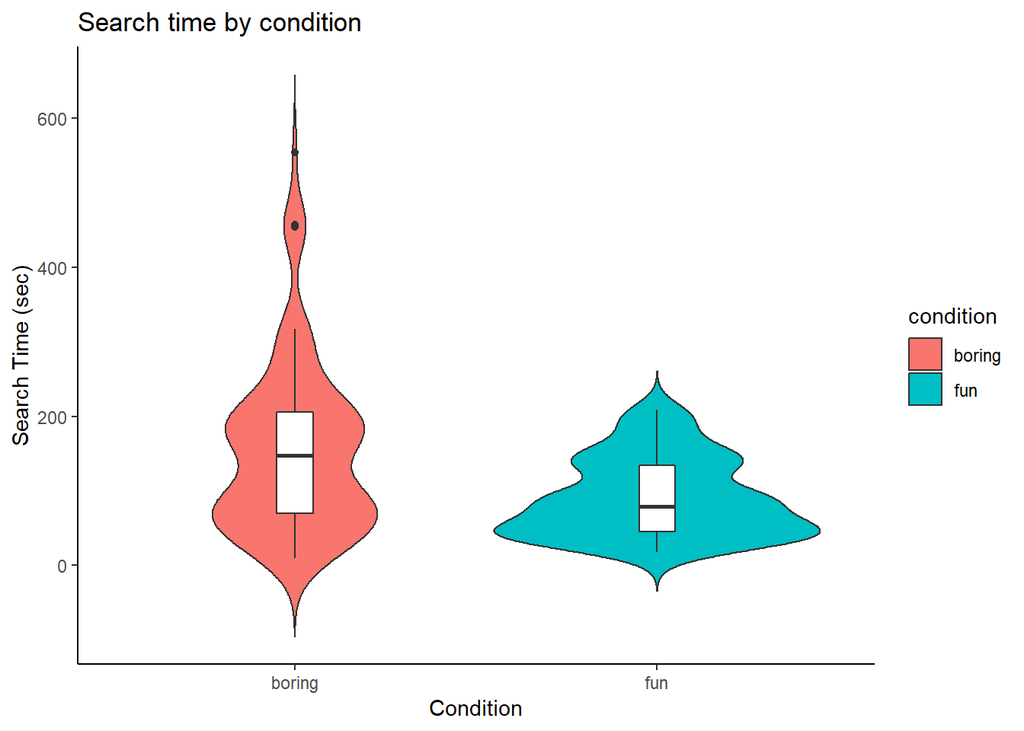

```r
#Search time (in seconds)

# Change color by groups
dp <- ggplot(bfwide, aes(x=condition, y=searchtime, fill=condition)) +
  geom_violin(trim=FALSE)+
  geom_boxplot(width=0.1, fill="white")+
  labs(title="Search time by condition",x="Condition", y = "Search Time (sec)")
dp + theme_classic()
```

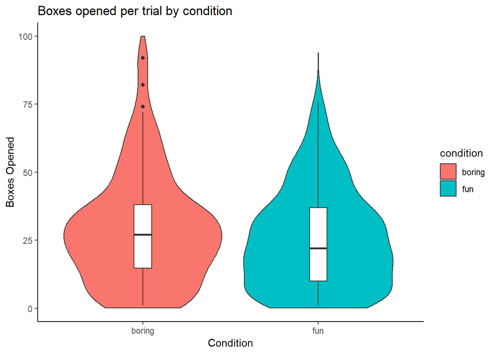

```r
#Boxes opened (raw count)

dp <- ggplot(bfwide, aes(x=condition, y=numopened, fill=condition)) +
  geom_violin(trim=FALSE)+ylim(0,100)+
  geom_boxplot(width=0.1, fill="white")+
  labs(title="Boxes opened per trial by condition",x="Condition", y = "Boxes Opened")
dp + theme_classic()
```

# 4. Basic inferential tests

## 4.1. Did the “contextual patience manipulation” (boring video) make people search longer?

Yes (even with only 45 per cell from the Pilot)

```r
m1a<-lmer(searchtime~patientcond+(1|ip),data=bfwide)
summary(m1a)
```

```
## Linear mixed model fit by REML. t-tests use Satterthwaite's method [
## lmerModLmerTest]
## Formula: searchtime ~ patientcond + (1 | ip)
##    Data: bfwide
##
## REML criterion at convergence: 1589.7
##
## Scaled residuals:
##     Min      1Q  Median      3Q     Max
## -7.2690 -0.0020 -0.0003  0.0015  4.8416
##
## Random effects:
##  Groups   Name        Variance  Std.Dev.
##  ip       (Intercept) 8622.0871 92.8552
##  Residual                0.6599  0.8123
## Number of obs: 267, groups:  ip, 91
##
## Fixed effects:
##             Estimate Std. Error    df t value Pr(>|t|)
## (Intercept)    90.66      13.40 89.00   6.764 1.36e-09 ***
## patientcond    65.95      19.50 89.00   3.383  0.00107 **
## ---
## Signif. codes:  0 '***' 0.001 '**' 0.01 '*' 0.05 '.' 0.1 ' ' 1
##
## Correlation of Fixed Effects:
##             (Intr)
## patientcond -0.687
```

```r
#log transformation of search time, to reduce skewness
m1b<-lmer(logtime~patientcond+(1|ip),data=bfwide)
summary(m1b)
```

```
## Linear mixed model fit by REML. t-tests use Satterthwaite's method [
## lmerModLmerTest]
## Formula: logtime ~ patientcond + (1 | ip)
##    Data: bfwide
##
## REML criterion at convergence: -623.9
##
## Scaled residuals:
##     Min      1Q  Median      3Q     Max
## -7.3101 -0.0171  0.0063  0.0210  4.7998
##
## Random effects:
##  Groups   Name        Variance  Std.Dev.
##  ip       (Intercept) 0.1070568 0.32720
##  Residual             0.0006879 0.02623
## Number of obs: 267, groups:  ip, 91
##
## Fixed effects:
##             Estimate Std. Error       df t value Pr(>|t|)
## (Intercept)  1.87970    0.04728 88.94870  39.758   <2e-16 ***
## patientcond  0.17433    0.06878 88.96141   2.534    0.013 *
## ---
## Signif. codes:  0 '***' 0.001 '**' 0.01 '*' 0.05 '.' 0.1 ' ' 1
##
## Correlation of Fixed Effects:
##             (Intr)
## patientcond -0.687
```

## 4.2. Did the “contextual patience manipulation” (boring video) cause people to open more boxes?

Not significantly, although the Pilot only had 45 per cell

```r
m2a<-lmer(totalfix~patientcond+(1|ip),data=bfwide)
summary(m2a)
```

```
## Linear mixed model fit by REML. t-tests use Satterthwaite's method [
## lmerModLmerTest]
## Formula: totalfix ~ patientcond + (1 | ip)
##    Data: bfwide
##
## REML criterion at convergence: 2488.9
##
## Scaled residuals:
##     Min      1Q  Median      3Q     Max
## -2.2650 -0.5087 -0.1864  0.3054  7.1273
##
## Random effects:
##  Groups   Name        Variance Std.Dev.
##  ip       (Intercept) 251.3    15.85
##  Residual             499.9    22.36
## Number of obs: 267, groups:  ip, 91
##
## Fixed effects:
##             Estimate Std. Error     df t value Pr(>|t|)
## (Intercept)   27.729      2.966 90.002   9.348 6.48e-15 ***
## patientcond    6.209      4.326 90.087   1.435    0.155
## ---
## Signif. codes:  0 '***' 0.001 '**' 0.01 '*' 0.05 '.' 0.1 ' ' 1
##
## Correlation of Fixed Effects:
##             (Intr)
## patientcond -0.686
```

```r
#log transformation of boxes opened, to reduce skewness
m2b<-lmer(logfix~patientcond+(1|ip),data=bfwide)
summary(m2b)
```

```
## Linear mixed model fit by REML. t-tests use Satterthwaite's method [
## lmerModLmerTest]
## Formula: logfix ~ patientcond + (1 | ip)
##    Data: bfwide
##
## REML criterion at convergence: 207
##
## Scaled residuals:
##     Min      1Q  Median      3Q     Max
## -2.2345 -0.4744  0.0457  0.5694  3.5190
##
## Random effects:
##  Groups   Name        Variance Std.Dev.
##  ip       (Intercept) 0.09790  0.3129
##  Residual             0.07202  0.2684
## Number of obs: 267, groups:  ip, 91
##
## Fixed effects:
##             Estimate Std. Error       df t value Pr(>|t|)
## (Intercept)  1.30895    0.05054 89.39470  25.900   <2e-16 ***
## patientcond  0.06368    0.07367 89.79005   0.864     0.39
## ---
## Signif. codes:  0 '***' 0.001 '**' 0.01 '*' 0.05 '.' 0.1 ' ' 1
##
## Correlation of Fixed Effects:
##             (Intr)
## patientcond -0.686
```

## 4.3. Did the “contextual patience manipulation” (boring video) make people more accurate in their credit card choices?

Yes (accuracy is 36% compared to 19% in impatient condition; p = .06)

```r
bfwidet1<-bfwide[(bfwide$trial==1), ]

m3<-glmer(correct~patientcond+(1|ip),data=bfwidet1,family=binomial,control=glmerControl(optimizer="bobyqa",optCtrl=list(maxfun=2e5)))
summary(m3)
```

```
## Generalized linear mixed model fit by maximum likelihood (Laplace
##   Approximation) [glmerMod]
##  Family: binomial  ( logit )
## Formula: correct ~ patientcond + (1 | ip)
##    Data: bfwidet1
## Control:
## glmerControl(optimizer = "bobyqa", optCtrl = list(maxfun = 2e+05))
##
##      AIC      BIC   logLik deviance df.resid
##    110.0    117.6    -52.0    104.0       89
##
## Scaled residuals:
##     Min      1Q  Median      3Q     Max
## -0.7559 -0.7559 -0.4804  1.3229  2.0817
##
## Random effects:
##  Groups Name        Variance Std.Dev.
##  ip     (Intercept) 0        0
## Number of obs: 92, groups:  ip, 91
##
## Fixed effects:
##             Estimate Std. Error z value Pr(>|z|)
## (Intercept)  -1.4663     0.3698  -3.965 7.33e-05 ***
## patientcond   0.9067     0.4847   1.871   0.0614 .
## ---
## Signif. codes:  0 '***' 0.001 '**' 0.01 '*' 0.05 '.' 0.1 ' ' 1
##
## Correlation of Fixed Effects:
##             (Intr)
## patientcond -0.763
## convergence code: 0
## singular fit
```

## 4.4 Is the relationship between beta and search larger in one condition than the other?

(Eric’s moderator hypothesis)

No, but there may have been some issues when running Qi’s estimation script (“divergent transitions” so perhaps some things failed to converge and caused problems)

```r
bfwide$beta.c<-bfwide$beta-mean(bfwide$beta,na.rm=TRUE)
bfwide$delta.c<-bfwide$delta-mean(bfwide$delta,na.rm=TRUE)
bfwide$patientcond.c<-bfwide$patientcond-.5

m4a<-lmer(logtime~beta.c*patientcond.c+delta.c*patientcond.c+(1|ip),data=bfwide)
summary(m4a)
```

```
## Linear mixed model fit by REML. t-tests use Satterthwaite's method [
## lmerModLmerTest]
## Formula: logtime ~ beta.c * patientcond.c + delta.c * patientcond.c +
##     (1 | ip)
##    Data: bfwide
##
## REML criterion at convergence: -622.3
##
## Scaled residuals:
##     Min      1Q  Median      3Q     Max
## -7.3096 -0.0156  0.0041  0.0203  4.8003
##
## Random effects:
##  Groups   Name        Variance  Std.Dev.
##  ip       (Intercept) 0.1093842 0.33073
##  Residual             0.0006879 0.02623
## Number of obs: 267, groups:  ip, 91
##
## Fixed effects:
##                       Estimate Std. Error       df t value Pr(>|t|)
## (Intercept)            1.97197    0.03500 84.96026  56.344   <2e-16 ***
## beta.c                 0.03338    0.12469 84.95178   0.268   0.7896
## patientcond.c          0.17742    0.07000 84.96026   2.535   0.0131 *
## delta.c                0.10457    0.28478 84.95721   0.367   0.7144
## beta.c:patientcond.c  -0.03935    0.24939 84.95178  -0.158   0.8750
## patientcond.c:delta.c  0.70056    0.56956 84.95721   1.230   0.2221
## ---
## Signif. codes:  0 '***' 0.001 '**' 0.01 '*' 0.05 '.' 0.1 ' ' 1
##
## Correlation of Fixed Effects:
##             (Intr) beta.c ptntc. delt.c bt.c:.
## beta.c      -0.006
## patintcnd.c  0.053 -0.037
## delta.c     -0.003 -0.450  0.115
## bt.c:ptntc. -0.037  0.188 -0.006 -0.070
## ptntcnd.c:.  0.115 -0.070 -0.003  0.015 -0.450
```

```r
m4b<-lmer(logfix~beta.c*patientcond.c+delta.c*patientcond.c+(1|ip),data=bfwide)
summary(m4b)
```

```
## Linear mixed model fit by REML. t-tests use Satterthwaite's method [
## lmerModLmerTest]
## Formula: logfix ~ beta.c * patientcond.c + delta.c * patientcond.c + (1 |
##     ip)
##    Data: bfwide
##
## REML criterion at convergence: 206
##
## Scaled residuals:
##     Min      1Q  Median      3Q     Max
## -2.2721 -0.4721  0.0362  0.5472  3.5363
##
## Random effects:
##  Groups   Name        Variance Std.Dev.
##  ip       (Intercept) 0.09725  0.3119
##  Residual             0.07212  0.2686
## Number of obs: 267, groups:  ip, 91
##
## Fixed effects:
##                       Estimate Std. Error       df t value Pr(>|t|)
## (Intercept)            1.34603    0.03704 85.95642  36.337   <2e-16 ***
## beta.c                 0.18117    0.13174 85.48697   1.375    0.173
## patientcond.c          0.07009    0.07409 85.95642   0.946    0.347
## delta.c                0.10006    0.30126 85.86805   0.332    0.741
## beta.c:patientcond.c   0.01331    0.26349 85.48697   0.051    0.960
## patientcond.c:delta.c  0.59346    0.60253 85.86805   0.985    0.327
## ---
## Signif. codes:  0 '***' 0.001 '**' 0.01 '*' 0.05 '.' 0.1 ' ' 1
##
## Correlation of Fixed Effects:
##             (Intr) beta.c ptntc. delt.c bt.c:.
## beta.c      -0.001
## patintcnd.c  0.058 -0.032
## delta.c      0.003 -0.439  0.125
## bt.c:ptntc. -0.032  0.191 -0.001 -0.061
## ptntcnd.c:.  0.125 -0.061  0.003  0.020 -0.439
```